# 强化学习（32B 税务模型 · think 去检索腔）

# 强化学习（32B 税务模型 · think 去检索腔）

> **实验周期：2026.6.8 — 2026.6.24**

> **一句话目标**：公司 V1 税务大模型（Qwen2.5-32B 微调）对外宣称”端到端推理”，但它的 `<think>` 里满是”参考问答对N / 资料显示 / 检索结果”这类检索腔，像机器念手册不像人。本项目用强化学习把 V1 的 think **去检索腔**——在**不让答案漂离 V1 自己认可范围**（不损答案准确率）的前提下，让 think 变成自然推导。成功则把配方迁回 V1。

## 验收用的三个量（全程统一，先记住这三个名字）

所有指标都在**冻结的 500 题验收集**上量。一件事只交给最擅长它的一把判据：

| 指标 | 它判什么 | 谁来判 | 单次 / 多次 |
| --- | --- | --- | --- |
| **kimi think**（干净分 0–10） | think 有没有**换词复述照抄**（词换了、但还在逐条复述参考） | Kimi（语义判断） | **同一条打 3 次取平均** |
| **规则think**（通过率） | think 有没有**检索腔表面词**（“参考问答对/资料显示/检索结果”…） | 规则 `detect_rag_style` | 确定性、单次即准 |
| **规则answer**（在池率） | answer 有没有**漂离 V1 认可范围**（结论极性/数字/日期跑出 V1 会给的范围） | 规则 `answer_in_v1_pool` | 确定性、单次即准 |

> 不考核”答案对不对”，只考核”答案有没有漂离 V1”——V1 自己也会这么答 = 没偏移。**验收要求规则answer 在池率 ≥ 85%。**

> 链路：**V1 基线 → SFT（监督微调，先教会自然推导）→ RFT（拒绝采样微调，守住答案）→ DPO（偏好优化，把 think 继续推干净）→ GRPO（在线强化）**。

## 一. 实验结果总览

### 1.1 指标变化（含两个版本：原版 / 剔除格式失败版）

**① kimi think · 干净分（0–10，越高越没有”换词复述照抄”）**

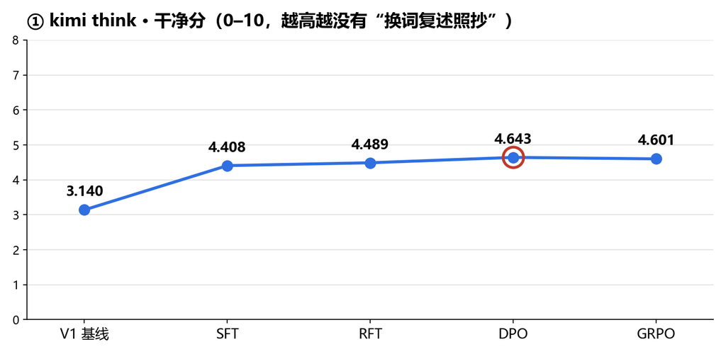

kimi think 干净分

**② 规则think · 通过率（越高越没有检索腔表面词）**

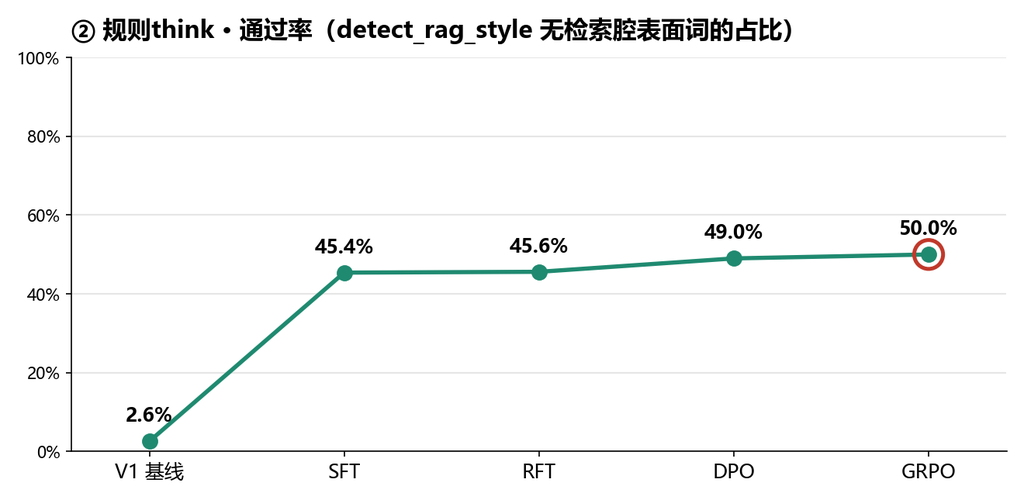

规则think 通过率

**③ 规则answer · 在池率（验收要求 ≥ 85%）**

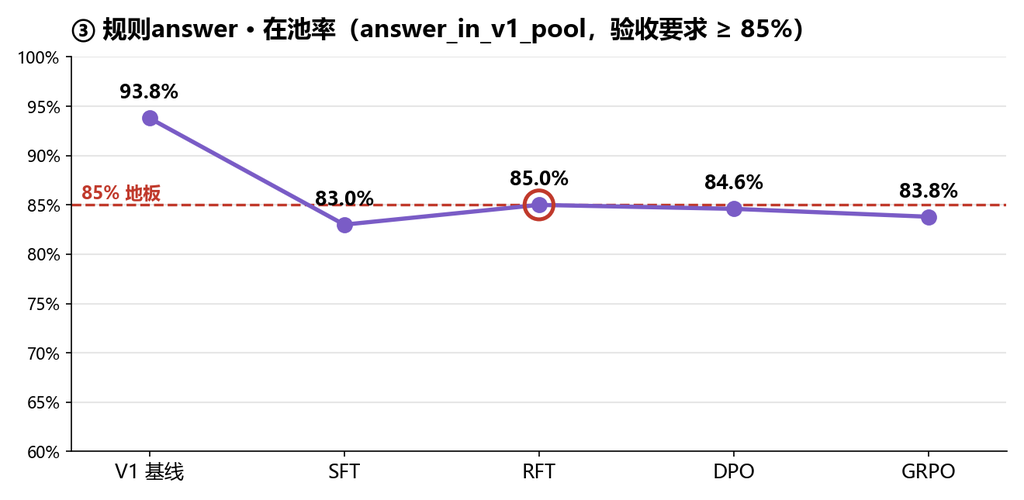

规则answer 在池率

#### 版本一 · 原版（格式失败题计入 500 分母，按失败计）

| 阶段 | kimi think 干净分 | 规则think 通过率 | 规则answer 在池率 | 格式失败 |
| --- | --- | --- | --- | --- |
| V1 基线 | 3.140 | 2.6% | 93.8% | 0 |
| SFT | 4.408 | 45.4% | 83.0% | 0 |
| RFT | 4.489 | 45.6% | 85.0% | 0 |
| **DPO（当前最好）** | **4.643** | 49.0% | **84.6%** | 1 |
| GRPO | 4.601 | **50.0%** | 83.8% | 2 |

#### 版本二 · 剔除格式失败后重算（只有 DPO/GRPO 含格式失败，其余三阶段无变化）

> 口径：模型输出格式坏的题（think 跑飞撞 `max_new_tokens` 没闭合 `</think>`、answer 为空）从分母里**剔掉**，三件套重算。DPO 剔 1 题（分母 499）、GRPO 剔 2 题（分母 498）。

| 阶段 | kimi think 干净分 | 规则think 通过率 | 规则answer 在池率 | 分母 |
| --- | --- | --- | --- | --- |
| V1 基线 | 3.140 | 2.6% | 93.8% | 500 |
| SFT | 4.408 | 45.4% | 83.0% | 500 |
| RFT | 4.489 | 45.6% | 85.0% | 500 |
| **DPO** | 4.637 | 49.1% | **84.8%**（423/499） | 499 |
| GRPO | 4.597 | 50.2% | 84.1%（419/498） | 498 |

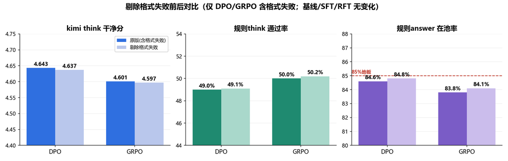

剔除格式失败前后对比

**两版对比读出来的结论**： - **剔掉格式失败题，三件套几乎不变**：DPO 在池率 84.6%→**84.8%**、GRPO 83.8%→**84.1%**，kimi think / 规则think 都只动小数点后一两位。**结论不翻盘——DPO、GRPO 两版都仍 < 85% 地板。** - **格式失败确实拉低了一点在池率**（每道格式失败题被算成”不在池”），GRPO 比 DPO 多 1 道格式失败，所以原版里 GRPO 比 DPO 多掉一点点；**但即使两边都剔干净，GRPO（84.1%）仍略低于 DPO（84.8%），差距 0.7 个点落在统计噪声内**（500 题二值比例的标准误约 1.6 个点）。

**怎么读这几张图（核心结论）**： - **SFT 一步就把 think 自然化打穿了**：kimi think **3.140→4.408**、规则think **2.6%→45.4%**，两件事**同时大涨**——第一次”双真涨”。代价是规则answer 在池率掉到 83.0%（破地板）。 - **RFT 专门把答案捞回**：规则answer 在池率 83.0%→**85.0%**（踩回地板），think 干净度没退。 - **DPO 是目前最好的一版**：kimi think **4.489→4.643**，**+0.155 越过”真涨门”≈0.15（来历见 1.3）→ 真涨、不是噪声**；规则think 涨到 49.0%。唯一没收口的是在池率 84.6%，差 0.4 个点没回 85%。 - **GRPO 与 DPO 统计上打平**：三件套差值全部落在噪声内（详见**三. GRPO 为什么没有特别突出**）。

### 1.2 各阶段模型输出对比（同一道题，重点标注）

取同一道验收题，看 think 从”满是检索腔（🔴）“到”自然推导（🟢）“的演化，以及答案如何被锁在 V1 范围内。

**【问题】** 公司在注销时，股东分红需要如何缴纳个人所得税？

**【参考问答对】**（RAG 检索回来的 5 条，节选）：股息红利所得按 **20%** 缴个税（参考1、3）；41 号公告终止投资按”财产转让所得”、注销清算实务一般按股息红利申报（参考2）；剩余财产分配顺序（参考4）；个税由股东承担、支付单位代扣代缴（参考5）。

#### V1 基线 — 规则think：🔴 **有痕迹** · kimi think 1.33 · 规则answer：在池

> think：🔴**根据参考问答对**，原始问题涉及公司注销时股东分红…🔴**参考问答对提供了多个相关知识点**：1.…按股息红利所得缴纳 20% 个税🔴**（参考问答对1）**。2.…🔴**回答引用国家税务总局公告 2011 年第 41 号**…🔴**（参考问答对2）**。…🔴**推理过程显式引用来源：步骤1来自参考问答对1和3；步骤2来自参考问答对1和3；步骤3来自参考问答对5…**

> answer：公司注销时…按 20% 税率缴纳个人所得税；建议与主管税局确认。

🔴 **被 `detect_rag_style` 命中的检索腔**：「根据参考问答对」「参考问答对提供了」「（参考问答对1）/（参考问答对2）」「推理过程显式引用来源：步骤X来自参考问答对…」——典型的”从资料向答案归纳、逐条标引用”。

#### SFT — 规则think：🟢 **无痕迹** · kimi think 2.0 · 规则answer：在池

> think：🟢企业注销时，股东分红涉及个人所得税的处理。**首先**，根据《公司法》第二百三十六条，公司财产在支付清算费用、职工工资、社保、税款和债务后，剩余财产按股东出资或持股比例分配。这意味着注销清算时，未分配利润的分配实质上是股东收回投资的行为。**其次**，个人股东从公司取得的股息、红利所得，适用 **20%** 的税率……**最后**，支付单位有义务代扣代缴……应按 20% 税率缴纳，并建议与主管税局确认执行口径。

> answer：注销清算时…按 **20%** 缴纳；建议跟主管税局确认。（= V1 原版答案）

🟢 没有任何”参考问答对/资料显示”字眼，从问题出发一步步推导，事实（20%、《公司法》第二百三十六条）全部保留。

#### RFT / DPO / GRPO — 规则think：🟢 **无痕迹** · kimi think 2.0 · 规则answer：在池

三个阶段都保持 SFT 的自然推导风格（规则think 全部无痕迹），措辞越来越顺。以 DPO/GRPO 为例：

> think：🟢企业注销时…**首先**根据《公司法》第二百三十六条…剩余财产按股东出资或持股比例分配…**其次**，自然人股东取得股息、红利所得适用 **20%** 税率，基于”利息、股息、红利所得”项目而非”财产转让所得”；**虽然存在 41 号公告**关于终止投资按”财产转让所得”征税的规定，**但注销清算中股权灭失的情形实务中通常仍按股息红利所得处理，各地口径可能不同，建议与主管税务机关确认**。**最后**，分配现金股利时个税由股东承担、支付单位代扣代缴……需按 **20%** 缴纳。

> answer：注销清算时…按 **20%** 缴纳；建议跟主管税局确认。（= V1 原版答案）

#### 同一道题五阶段对照

| 阶段 | 规则think | 规则answer | kimi think | answer 结论 |
| --- | --- | --- | --- | --- |
| V1 基线 | 🔴 有痕迹 | 在池 | 1.33 | 20% 股息红利所得 |
| SFT | 🟢 无痕迹 | 在池 | 2.0 | 20%（同 V1） |
| RFT | 🟢 无痕迹 | 在池 | 2.0 | 20%（同 V1） |
| DPO | 🟢 无痕迹 | 在池 | 2.0 | 20%（同 V1） |
| GRPO | 🟢 无痕迹 | 在池 | 2.0 | 20%（同 V1） |

**两点要读出来**： - **答案全程锁在 V1（answer-lock 的效果）**：五个阶段的 answer 结论都是”20% 股息红利所得 + 建议跟主管税局确认”，和 V1 原版一致——这是我们刻意用 V1 答案拼接训练的结果（见 1.4 / 二.4），就是为了让 think 去检索腔时**别把答案带歪**。 - **单条 kimi think 分很粗**：这道题 V1 1.33、其余阶段都 2.0，单条几乎分不出 SFT/RFT/DPO/GRPO 谁更干净——**真正能看出去检索腔的是规则think（有痕→无痕，干净利落）**；kimi think 要靠**整批 500 条的群体均值**（3.140→4.6）才准，单条别细抠（为什么”单条粗、群体准”，正是下一节 1.3 的内容）。

### 1.3 裁判精度测量（judgecal 标定）——单样本 vs 群体、不同精度/难度下的方差

“换词复述照抄”只能靠 Kimi 判（规则对换了词的照抄全盲）。但 Kimi 打分会抖，**所以动手训之前，先把 Kimi”能稳定分辨多大的差”量清楚**。

**做法**：13 个参考资料，每个人工写出 6 档脏度的 think（没抄 / 抄 1 句 / 抄 2 句 / 抄 3 句 / 抄 4 句 / 完全照抄，“抄”=换词复述），共 **78 条**；每条让 **Kimi 打 0–10 干净分、独立打 16 遍**。

#### 一个贯穿全节的例子（增值税小规模免税题）

**【参考资料】**（4 句规定）： > ① 增值税小规模纳税人月销售额未超过 10 万元的，免征增值税。 > ② 以 1 个季度为 1 个纳税期的，季度销售额未超过 30 万元的，免征增值税。 > ③ 适用差额征税政策的，以差额后的销售额确定是否免税。 > ④ 小规模纳税人销售不动产，应按规定预缴或申报缴纳增值税。

下面把同一道题的 6 档 think **每一句都列全**（不是节选）。标 🔸 的是”把某条规定换个说法复述了一遍”（= 照抄，扣分）；不标的是”自己在推、或把数字当判断条件用进来”（= 不算照抄）。从上往下，每多一档就多把一句规定改成复述：

**没抄**（0 句照抄 · 理想分 10 · Kimi 实测均值 **7.34**） > 这家小规模这个月到底免不免，先看它的销售额和申报方式。它本月销售额 9 万，没到 10 万这条线。把这些条件套到它的实际数上，就能下结论。它是按月报的，所以看月度这档、不看季度 30 万。结论是免还是缴，取决于冲减和申报口径，别只看表面数字。

**抄 1 句**（1 句照抄 · 理想分 8 · Kimi 实测均值 **4.64**） > 这家小规模这个月到底免不免，先看它的销售额和申报方式。🔸**小规模纳税人当月销售额若未达到 10 万元，即可享受免征增值税。**〔复述规定①〕它本月销售额 9 万，没到 10 万这条线。把这些条件套到它的实际数上，就能下结论。它是按月报的，所以看月度这档、不看季度 30 万。

**抄 2 句**（2 句照抄 · 理想分 6 · Kimi 实测均值 **2.64**） > 这家小规模这个月到底免不免，先看它的销售额和申报方式。🔸**小规模纳税人当月销售额若未达到 10 万元，即可享受免征增值税。**〔复述①〕🔸**若以一个季度作为纳税期，季度销售额在 30 万元以内的，同样予以免税。**〔复述②〕它本月销售额 9 万，没到 10 万这条线。把这些条件套到它的实际数上，就能下结论。

**抄 3 句**（3 句照抄 · 理想分 4 · Kimi 实测均值 **1.84**） > 这家小规模这个月到底免不免，先看它的销售额和申报方式。🔸**小规模纳税人当月销售额若未达到 10 万元，即可享受免征增值税。**〔复述①〕🔸**若以一个季度作为纳税期，季度销售额在 30 万元以内的，同样予以免税。**〔复述②〕🔸**涉及差额征税业务时，应以扣减后的销售额判定能否免税。**〔复述③〕它本月销售额 9 万，没到 10 万这条线。

**抄 4 句**（4 句照抄 · 理想分 2 · Kimi 实测均值 **0.03**） > 这家小规模这个月到底免不免，先看它的销售额和申报方式。🔸**小规模纳税人当月销售额若未达到 10 万元，即可享受免征增值税。**〔复述①〕🔸**若以一个季度作为纳税期，季度销售额在 30 万元以内的，同样予以免税。**〔复述②〕🔸**涉及差额征税业务时，应以扣减后的销售额判定能否免税。**〔复述③〕🔸**若发生不动产销售，小规模纳税人需依规定预缴或申报该税款。**〔复述④〕

**完全照抄**（4 句全照抄、没有一句自己的判断 · 理想分 0 · Kimi 实测均值 **0.00**） > 🔸**小规模纳税人当月销售额若未达到 10 万元，即可享受免征增值税。**〔复述①〕🔸**若以一个季度作为纳税期，季度销售额在 30 万元以内的，同样予以免税。**〔复述②〕🔸**涉及差额征税业务时，应以扣减后的销售额判定能否免税。**〔复述③〕🔸**若发生不动产销售，小规模纳税人需依规定预缴或申报该税款。**〔复述④〕

> **注意这两句的区别**（字面都带”10 万”，但一句加分、一句扣分，只有 Kimi 语义分得清、规则看字面分不出）： - 「它本月销售额 9 万，**没到 10 万这条线**」= 把数字 10 万**当判断条件用进推理**（不算照抄，**加分**）； - 🔸「**小规模纳税人当月销售额若未达到 10 万元，即可享受免征增值税**」= 把规定①**整句换个说法搬了一遍**（算照抄，**扣分**）。

#### 裁判分辨率阶梯：Kimi 实测 vs 理想锚点

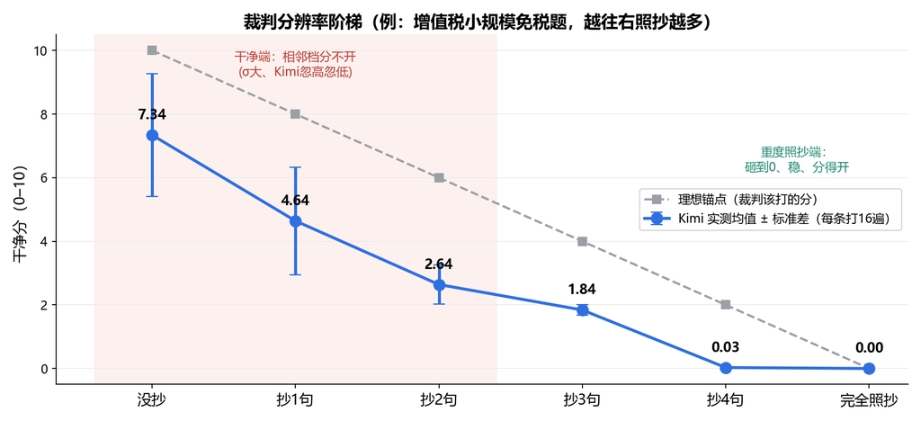

裁判分辨率阶梯

读出：① **整体单调、但系统性偏严**——连”没抄”也只给 7.34（不是 10）；② **顶端飘得离谱**——“没抄”标准差 1.93，有的全干净 think 被打到 2.75（当成挺脏的）；③ **底端一刀切到 0**——抄 4 句（0.03）和完全照抄（0.0）都砸到 ~0、分不开；④ **只有抄 3 句→抄 4 句这一跌是唯一分得开的相邻档**。

#### 关键区分：给一个样本打分 ≠ 给一批样本打分

- **群体评测（比模型阶段，如”DPO 比 RFT 干净没”）**：把 N 条各打几次、取**总平均**。N 条的噪声会**互相抵消**，总平均的标准误 ≈ 单条波动 ÷ √N。**N 越大越准**——所以验收用 500 条、每条只打 1~3 次就够（这就是 1.2 里”单条 1.33/2.0 看不出、整批 3.14→4.6 看得出”的原因）。
- **单样本判断（选哪条进训练）**：只有这一条、没有 N 可摊，**单条波动就是天花板**，只能靠同一条多打几遍压噪声——但下面会看到，多打也压不掉全部波动。

#### 裁判的方差拆成两块：一块能压、一块压不掉

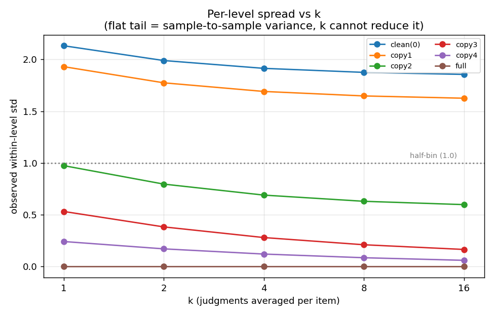

每档 std 随打分次数 k

- **σ_judge = 同一条反复打的噪声**：多打几遍 k 能压掉（按 √k 缩小）。
- **σ_between = 同一难度档里不同样本之间 Kimi 自己就判得不一致**：**多打也压不掉，是真天花板**。

读出：干净端（没抄/抄 1 句）的 σ_between ≈ 1.8/1.6，**打到 16 遍也几乎不降**——顶端的飘不是”打得不够多”，是 Kimi 对干净样本本身就忽高忽低。

#### 裁判方差随”任务难度”在变（同一把尺，难的地方飘、易的地方稳）

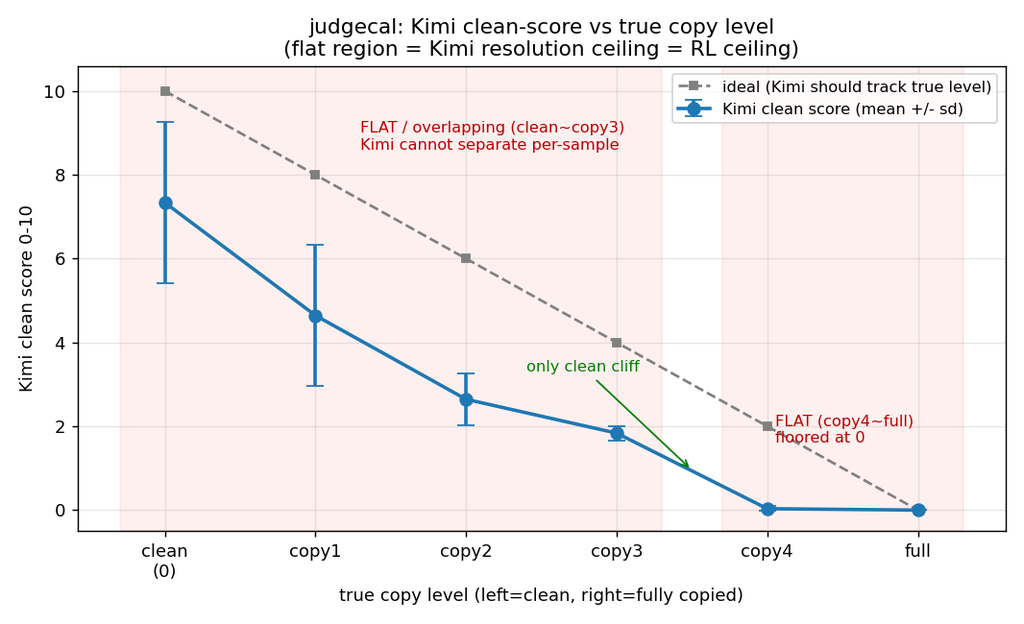

Kimi 干净分 vs 真实档位

**同一把 Kimi 尺，在不同难度的判断上方差差很多**：判”一个本来就干净的 think 到底多干净”——难、方差大（“没抄”标准差 1.93）；判”一个重度照抄”——易、方差几乎为 0（抄 4 句/完全照抄都砸到 ~0）。**所以裁判可靠不可靠不是一个固定数，取决于被判样本落在哪个难度档。**

#### 两两可分性：只有”干净 vs 重度照抄”分得开

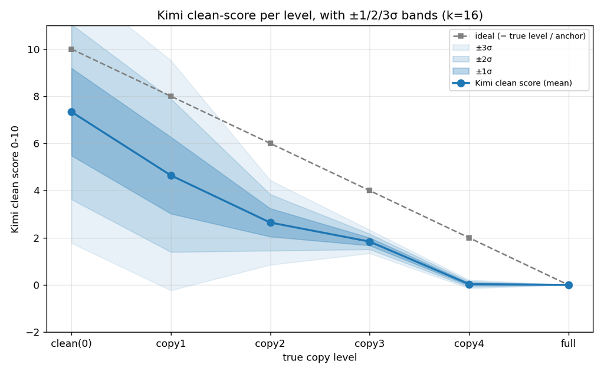

±1/2/3σ 带

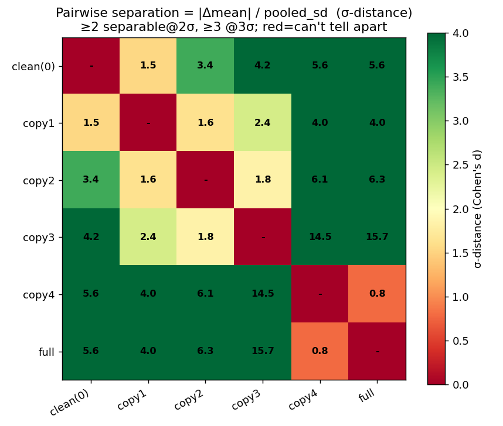

σ距离矩阵

#### 这把尺校准出的两条铁律（直接决定后面怎么训）

1. **逐条选训练样本：只能用”基本干净 vs 重度照抄”的大间距对子**（0~2 句的细微差 Kimi 分不出、还乱压分）。→ 钉死 DPO 对子的唯一造法：chosen=洗干净的 think（≈7）、rejected=V1 原版重度照抄的 think（≈1–2），中间档不用（见 1.4 / 1.7）。
2. **整体评测靠大 N 摊薄**：N=500、k=3 时，整批平均干净分的标准误 SE≈0.050 → **两阶段平均干净分差 > 约 3×SE ≈ 0.15 才算真涨**。**这就是 1.1 里判 DPO（+0.155）“真涨”的那道门。** 多打几遍几乎不改善（瓶颈是 σ_between，靠 √N 不靠 k）。

### 1.4 判据与奖励函数

**三把判据工具**（全程分工不变）：

| 工具 | 类型 | 判什么 | 输出 |
| --- | --- | --- | --- |
| `detect_rag_style`（`rules_v6.py`） | 确定性规则 | 检索腔**表面词**（A 检索装置腔 / B 编号引用 / C 客服话术 / D 图床附件） | 有痕 / 无痕 |
| `answer_in_v1_pool`（`rules_v6.py`） | 确定性规则 | answer 的**结论极性 + 数字 + 日期**在不在 V1 认可池里 | 在池 / 漂移 |
| Kimi 0–10 干净分（`judgecal_common.py`） | 语义裁判（k=3） | **换词复述照抄**程度 | 0–10 分 |

**选样门 `confident_cleaner`（2σ 带不相交）**——RFT/DPO 选样都用它，只留”Kimi 有把握判更干净”的：

```
gap = s_clean − s_dirty                                  # 候选比基线干净多少（Kimi 干净分之差）
留下 ⟺ gap > n_sigma · ( σ(s_clean) + σ(s_dirty) )       # σ 查 1.3 judgecal 标定表
RFT / DPO 选样取 n_sigma = 2.0（2σ 桶）
```

**DPO 偏好对（answer-lock 大间距对子）**——一对里只让 think 不同、答案锁死：

```
chosen   = <think>洗干净版（Kimi≈7）</think><answer>V1 原版答案</answer>
rejected = <think>V1 原版照抄版（Kimi≈1–2）</think><answer>同一个 V1 原版答案</answer>
           └ 两边 answer 逐字一致 → 梯度全压在 think 上，绝不动答案（answer-lock）
```

**GRPO 在线奖励函数**——分两段（先”热启动”、再”上 Kimi”，见 二.7）。GRPO 让模型对每题在线采一组候选，给每个打分。奖励是一棵**词典序硬门决策树**（`grpo_reward_plugin.py`），**越靠前的门越不可被后面补偿**：

```
格式坏（<think></think><answer></answer> 不齐）或 think 太短(<40字)  → -4.0
答案不在 V1 池（answer_in_v1_pool 判漂）                          → -3.0   ← Kimi 永远补不回来
答案在池但"不可比较"（无极性/数字/日期可比）                      → -2.0
以上都过 → 看 think：
   规则think 有痕迹(detect_rag_style)  → 0.50 + 0.20·kn − 重复罚 − 超长罚
   规则think 无痕迹                    → 1.00 + 0.40·kn − 重复罚 − 超长罚
   其中 kn = Kimi 干净分 / 10（归一到 0~1）
```

- **热启动段（warmup，30 步）**：只用规则+答案硬门，**不调 Kimi**（kn=0）——零噪声把”答案在池/格式”稳住。
- **在线段（online，90 步）**：在热启动产物上续训，**才接 Kimi（k=2）**，且 Kimi 只在”已过硬门的安全档内做组内排序”，不是硬门。

### 1.5 各阶段提示词（全文）

提示词决定模型/裁判的行为，这里把各阶段用的完整提示词列出。

**① V1 基线推理 — 系统提示（RAG 腔，`config.SYSTEM_PROMPT`）**：检索腔的来源就在这里。

```
你是一个乐于助人的AI助手。你的任务是基于提供的参考问答对来回答用户的问题。工作流程：
1. 仔细分析用户的问题
2. 在参考问答对中搜索相关信息
3. 基于参考内容组织回答，确保信息的准确性和相关性
4. 如果参考问答对中有完全匹配的问题，直接使用对应的答案
5. 如果参考问答对中没有直接匹配，但有关联信息，综合这些信息给出回答
最后为用户提供答案推理过程和答案分别包含在<think> </think>和<answer> </answer>标签中。
```

**② 训练后所有模型推理 — 系统提示（去检索腔，`config.COLDSTART_SYSTEM_PROMPT`）**：SFT/RFT/DPO/GRPO 推理与训练数据都用它。

```
你是一名专业的中文税务助手。你的推理与结论【必须严格依据已知资料中的事实、政策口径与数字】，
不得凭记忆臆测，更不得给出与已知资料相矛盾的结论；只有已知资料未覆盖的细节才可谨慎使用常识补充。
但表达上要像一位资深税务老师那样，把这些依据自然地融进思考、从问题一步步推导到结论，
而不是罗列或复述「参考问答对」「资料编号」「检索结果」这类字样。
把推理过程放在 <think> </think>、最终答案放在 <answer> </answer> 标签中。
```

**③ SFT 改写 — Kimi 改写提示词（系统，`rewrite_v2.REWRITE_SYSTEM`，四铁律）**：SFT 训练种子就是 Kimi 按这个把 V1 的 think 改干净的。**关键是不喂 V1 的 think，让 Kimi 从问题从头推**。

```
你是一位资深税务师。现在给你一道税务题的【事实依据】、【用户问题】和这道题【已锁定的结论】。
请你从用户问题出发，像自己当场盘这道题一样，一步步推到那个结论，写出一段第一人称的真实思考过程。
判分的人只数一件事：你有几句是在"把事实依据里的某一段，换个说法重新讲了一遍"——越少分越高。
[坏✗ 复述依据]"月销售额未超过10万元的小规模纳税人可以免征增值税，所以本月免征。"
[好✓ 把事实用进判断]"先看这个月卖了多少——9万；小规模免税线是10万，9万还在线里没踩，这部分增值税就免了。"
四条铁律，违反任何一条都算失败：
 一、不复述：绝不整句陈述规定本身，不逐条转述/归纳/对照依据。
 二、不检索腔：绝不出现 参考问答对/参考资料/检索结果/资料显示/根据上述资料/问答对X/问题X：/回答：/
     小贴士/温馨提示/您可以参考 等字眼；不许成串罗列文号或用"政策依据：/参考文件："起头甩文号
     （把单个文号自然嵌进一句推理可以）。
 三、事实与结论锁死：每个税率/百分比/金额/数字/日期/期限及结论极性都必须取自【事实依据】、与【已锁定的结论】一致；
     绝不臆造新数字、绝不推出相反或更宽更严的判断。
 四、只输出第一人称思考过程本身，第一句直接切题，不写答案、不要任何标签解释。
宁可写得简短、句句在推，也不要为了显得专业而堆砌——多写的句子最容易变成复述依据，反而丢分。
```

**SFT 改写 — 模板（池锚点版，`rewrite_v2.REWRITE_TEMPLATE_POOL`）**：用 V1 答案池抽出的”极性+数字”当锚点（正是 `answer_in_v1_pool` 的覆盖靶子），而不是给整段答案原文。

```
【用户问题】{query}
【事实依据】（唯一取数来源：只能取具体数字与口径用进推理，绝不许逐句转述或换说法重述它）{reference}
【必须命中的结论与数字（V1 认可范围：推导必须自然收束到这个结论方向，全程只能用下列数字，
  绝不能冒出这之外的数字、也不得推出相反结论）】{anchor}
现在开始写你的推导过程（只输出思考过程本身，不写答案，不要任何标签或解释）：
```

**④ Kimi 干净分 — 评分提示词（`judgecal_common.CLEAN_SCORE`）**：1.1 的 kimi think、RFT/DPO 的 2σ 选样门、GRPO 在线的 Kimi 排序，全都用它。

```
[系统] 你是税务 think 的『换词复述照抄』程度评分员。给整段 think 打一个 0-10 的『干净分』：
       完全没有换词复述照抄=10 分，整段几乎都是把参考逐条换词复述=0 分。只输出 JSON。
[模板] 评分锚点（6 档，照抄越多分越低）：
  10 分=完全没照抄（全从问题自己推，或只是把事实自然用进推理）；8 分=只有 1 句换词复述；
  6 分=2 句；4 分=3 句；2 分=4 句或更多；0 分=整段几乎每句都在复述。
  关键：把参考里的事实自然用在推理里【不算照抄】；只有"整句在复述参考某段"才算。
  不要因为篇幅长/用词正式/含专业术语就扣分。
  【参考资料】{reference}【think】{think}
  只输出 JSON：{"clean_score":0到10之间的数字,"n_copied_est":换词复述句数,"reason":"一句话理由"}
```

> 规则 `detect_rag_style`、`answer_in_v1_pool` 是确定性正则规则、**没有提示词**；GRPO 在线奖励用的就是上面这把规则 + ④ 的 Kimi 干净分。

### 1.6 Lora 分支追踪

```
base = V1-32B/checkpoint-1500   (公司 V1，Qwen2.5-32B 微调；65.5GB / 14 分片；只读、不动)
  │
  └─ v2-sft-*-lora                       = SFT   (从 base 练，k2-930 改写种子，ep7)
        └─ v2-rft-2sigma-2s-merged       = RFT   (2σ 桶自采样续练；已合并成完整底座 = DPO 起点)
              └─ v2-dpo-2sigma-2s-2s-lora / -merged
                                         = DPO   (885 条 answer-lock 大间距对子)   ★ 当前最好
                    └─ v2-grpo-warmup-2s-2s-2s-merged   (热启动：规则+答案，30 步)
                          └─ v2-grpo-2sigma-2s-2s-2s-lora / -merged
                                         = GRPO  (在线：+Kimi k=2，90 步)
```

### 1.7 数据追踪

**数据底盘**：2239 条老师输出（每条 = 问题 + 参考问答对 → V1 的 think+answer）→ 切成 **冻结验收集 500 条 + 训练集 1739 条**（全程冻结，所有阶段都在这 500 上验收）。 **V1 认可池**：让原始 V1 对全部 2239 题各采 **贪心 1 遍 + 采样 8 遍（温 0.8）= 9 条/题**，收集每题答案的”结论极性 + 关键数字 + 日期”集合 = 该题的 V1 认可池（`152_v1_support.v2.jsonl`，2239 条）。

**SFT（k2-930 → 837 训练 + 93 早停）** - **来源**：1739 训练题的 V1 think。 - **怎么洗**：Kimi 离线改写（**不喂 V1 think、池锚点**，见 1.5 ③；只改 think、不动 answer）。改写后 Kimi 干净分可达 **7.11**。 - **三道门**：① 规则门 `detect_rag_style`（无表面词）∧ ② facts 极性门（没引入新数字/新极性）∧ ③ **k=2 门**（Kimi 各打 2 次都判改写比 V1 干净）。 - **怎么丢**：1739 → **930** → 拆成 **837 训练 + 93 自然腔早停集**。`COLDSTART_EPOCHS=7`（约 100 步）。 - **结果**：kimi think 3.140→**4.408**、规则think 2.6%→**45.4%**、规则answer 在池 93.8%→83.0%。

**RFT（2σ 桶 → 204 条）** - **来源**：SFT 模型对 1739 训练题**每题自采 32 个**（`151_rft_selfsample.2s.v2.jsonl`，1739 行）。 - **筛选**：规则先筛 → 幸存候选 Kimi **k=16 双评** → 过 **2σ 门** `confident_cleaner` + 答案门（只留答案没漂的）→ **204 条**（3σ 桶 122 条）。 - **合并**：RFT adapter 合并进底座 = `v2-rft-2sigma-2s-merged` = DPO 起点。 - **结果**：kimi think→**4.489**、规则think→**45.6%**、规则answer 在池 83.0%→**85.0%**（捞回地板）。

**DPO（885 对）** - **构造**：answer-lock 大间距对子（chosen=洗净 think Kimi≈7 + V1 答案；rejected=V1 原脏 think Kimi≈1–2 + 同一 V1 答案）。只用 1.3 标定出”稳分得开”的对子，中间档不用。 - **怎么丢**：2σ 桶 **885 对**（3σ 桶 478 对，本轮用 885 对版）。108 步，AutoDL 2×A800。 - **结果**：kimi think→**4.643**（+0.155 真涨）、规则think→**49.0%**、规则answer 在池 **84.6%**。

**GRPO（在线，训练数据 1668 题）** - **来源**：1739 训练题**过滤掉 71 道”不可训练”的题**（V1 认可池无可比较事实）→ **1668 题**；在线对每题现采一组候选。 - **奖励**：1.4 那棵词典序硬门（热启动只用规则+答案 30 步 → 在线 +Kimi k=2 90 步）。 - **结果**：kimi think **4.601**、规则think **50.0%**、规则answer 在池 **83.8%**。

| 步骤 | 训练数据（怎么从底盘合成的） | 验收（kimi think / 规则think / 规则answer） |
| --- | --- | --- |
| SFT | 1739 V1 think · Kimi 改写（池锚点）· 三道门→**930**（837+93）· ep7 | 4.408 / 45.4% / 83.0% |
| RFT | SFT 对 1739 题各采 32 · 规则筛+Kimi k16 双评+**2σ 门**+答案门→**204** | 4.489 / 45.6% / 85.0% |
| DPO | **885 对** answer-lock 大间距对子（洗净 think vs V1 脏 think，共用 V1 答案） | 4.643 / 49.0% / 84.6% |
| GRPO | **1668 题**（1739 去 71 不可训练）在线采样 + 词典序硬门奖励（热启动→+Kimi） | 4.601 / 50.0% / 83.8% |

## 二. 经验记录（给后续项目沉淀的方法论）

### 1. 怎么”识别”模型身上有没有强化学习信号——拿 V1 当参照物把信号逼出来

强化学习的本质是”捞模型自己采样里的好样本、奖好惩坏”，但先有个问题：**怎么知道采样里有没有好样本可学？** 直接问”这条 think 绝对算不算好”很难（没 ground truth）。解法是**把判据从”绝对好不好”改成”比 V1 自己干净不干净”**——V1 的 think 是天然脏基线，只要 Kimi 有把握（2σ）判某条候选比 V1 那条更干净，就算找到一个可学的好样本。**RFT 能选出 204 条 2σ 候选、把在池率从 83% 拉回 85%，就是”信号存在”的证据。** > 沉淀：模型自身的强化信号微弱难测；**给它一个参照物（V1），把”绝对判断”换成”相对判断”，信号就被凸显出来**。

### 2. RFT 的定位——它只是”信号探测器”，重心不该压在它身上

RFT 在这条链里**主要作用是验证”模型有没有 RL 信号”**，不是产出最终模型。它把答案捞回地板、证明能选出比 V1 干净的样本，任务就完成了。**真正吃到 think 去检索腔大头的是 SFT（教会）和 DPO（强化）。** 不必在 RFT 上反复调参求涨。

### 3. DPO 为什么用 V1 来构造正负对——保证每题都有一对”分得开”的对子

1.3 的结论：Kimi 逐条只分得开”干净 vs 重度照抄”的大间距对子。坏样本（脏 think）从哪来？**直接拿 V1 原版 think 当坏样本**——它天然就是重度照抄（Kimi≈1–2），每题都现成；正样本用 Kimi 洗干净的改写（≈7）。于是**每道题都能配出一对天然 3σ 可分的对子**（正好落在 Kimi 唯一分得开的区间），不需要模型先采出脏样本。这就是”用 V1 构造正负对”的意图：**把判据的能力边界（只分得开大间距）和数据构造方式对齐**。

### 4. 整条链都用 V1 的答案拼接——为了”去检索腔 think”时别把答案带歪

贯穿全链的护栏：**SFT 改写只改 think 不动 answer、DPO 对子 chosen/rejected 共用同一段 V1 原版 answer（answer-lock）、GRPO 把”答案在池”设成不可补偿硬门**——全部围绕一个目的：**优化只作用在 think 上，答案始终锚定 V1。** V1 答案是公司验过、准确率有保证的基线；1.2 那道题五个阶段答案都锁在”20% 股息红利”就是这条护栏在起作用。 > 沉淀：当优化目标（think 自然化）和约束（答案别变）耦合时，**“锁住一个、只让另一个动”（answer-lock）比用一个复合奖励同时管两件事更稳**——后者会让两个信号互相稀释。

### 5. ★裁判水平的把控（最重要的一条）

裁判（Kimi）是整个项目的”测量仪器”，仪器不准则一切结论不可信。要点（机制见 1.3）： - **先分清”给一个样本打分”还是”给一批样本打分”**：给一批（比模型阶段）靠样本量 N 互相抵消噪声、N 越大越准（验收用 500 条）；给一个（选训练样本）没有 N 可摊，只能多打几遍、而且压不掉”样本间分歧”那部分。 - **一定要实测裁判在不同精度下的方差**（judgecal 干的事）：把方差拆成”能靠多打压掉的 σ_judge”和”压不掉的 σ_between”。 - **裁判方差随样本量增大而减小**（群体 SE 随 √N 下降），**但同一把尺在不同难度任务上方差不一样**：判”干净样本多干净”方差大（不可靠）、判”重度照抄”方差小（可靠）。**不能笼统说裁判准不准，要说它在哪个难度档准**——这决定了哪些训练对子能用（只用大间距对子）。 > 沉淀：上奖励/选样之前，**先花零训练成本把裁判标定出来**（σ_judge / σ_between / 真涨门 = 3×SE / 各难度档方差）。否则要么在噪声里空跑、要么拿一把在该难度档不可靠的尺去选样、污染训练。

### 6. ★分清”结构性问题”和”表面性问题”——奖励函数只能解决表面性的

设计在线强化（GRPO/PPO）奖励时最该提前想清楚的： - **表面性问题**：检索腔表面词、图床链接、编号罗列——**字面可枚举，确定性规则（`detect_rag_style`）零噪声判准**，能当强梯度奖励。 - **结构性问题**：换词复述照抄（词换了、没有任何字面词，但整段还是”从资料向答案归纳”）——**规则完全看不见，只能靠大模型（Kimi）或人判**。

**奖励函数（规则）只能解决表面性问题；结构性问题必须有大模型或人介入。** 而大模型判结构性问题又有 1.3 那个分辨率限制（逐条只分得开大间距）。所以在线 RL 的奖励必须**提前把两类解耦**：表面性 → 确定性规则（零噪声强梯度、可当硬门）；结构性 → 要么**离线**用 Kimi/人标成大间距对子喂 DPO（本项目 DPO 的 +0.155 就是这么拿到的），要么接受”在线只能用 Kimi 做粗排序、给不了多少梯度”。**不能图省事用”一个去检索腔单指标”当在线 reward**——会被模型钻空子（换说法接着复述、还顺手把答案弄漂），即 Goodhart。

### 7. GRPO 的”热启动”（warmup）——先用零噪声硬门稳住，再上带噪声的裁判

GRPO 在线训练分两段，这个顺序本身是条经验： - **先热启动（30 步，只用规则+答案硬门，不调 Kimi）**：DPO 起点的策略刚拿过来，先用**零噪声的确定性信号**（格式、答案在池、规则think 档位）把硬约束焊牢、把策略”焐热”到稳定点。 - **再上在线 Kimi（90 步）**：在热启动产物上才接入带噪声的语义裁判（Kimi k=2，只做组内排序）。 - **为什么不一上来就用 Kimi**：Kimi 单条打分抖（1.3），一开始就让它主导奖励，噪声会在策略还不稳时把它带偏；先用确定性硬门把地基打稳，再让噪声裁判做”锦上添花”的微调，更不容易训崩。 > 沉淀：在线 RL 引入带噪声的奖励分量时，**先用确定性、零噪声的分量做一段热启动把硬约束和策略稳住，再叠加噪声分量**，是更稳的课程式做法。

### 8. 数据选样：SFT 要先到一个”门槛水平”，RL 信号才显现，这个门槛得做实验估

强化学习只能放大”模型已经偶尔会做”的行为。**SFT 没到位（采样里根本没有干净样本），后面 RFT/DPO/GRPO 就没有正样本可学、必死。** 本项目里 SFT 必须先把规则think 从 2.6% 拉到 ~45%、kimi think 拉到 4.4，DPO 才有发挥空间。**“SFT 要到什么水平 RL 才有信号”没有公式，得做实验不断试**（换改写法、调种子量和 epoch，盯着”采样里有没有干净候选”这个先行指标），这一步的投入产出比比在 RL 阶段反复调参高得多。

## 三. GRPO 为什么没有特别突出（只做原因分析）

先把账算清——**GRPO 相对 DPO，三个指标的变化全部落在统计噪声内，没有一项是真实变化**：

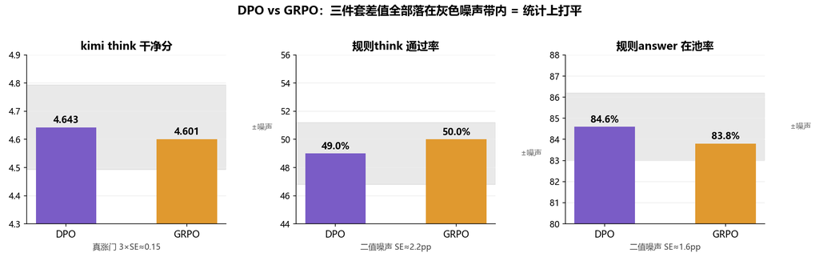

DPO vs GRPO 噪声带

| 指标 | DPO | GRPO | 变化 | 噪声门槛 | 判读 |
| --- | --- | --- | --- | --- | --- |
| kimi think 干净分 | 4.643 | 4.601 | −0.042 | 真涨门 3×SE≈0.15 | 持平（远没过门） |
| 规则think 通过率 | 49.0% | 50.0% | +1.0pp | 二值比例 SE≈2.2pp | 微涨、在噪声内 |
| 规则answer 在池率 | 84.6% | 83.8% | −0.8pp | 二值比例 SE≈1.6pp | 持平、在噪声内 |

- **kimi think 基本没动**（−0.04，“保持不变”是对的）；**规则think 涨了 1 个点**；**规则answer 在池率那 0.8 个点的”降”，一部分是分母里多了 1 道格式失败题**（GRPO 2 题 vs DPO 1 题；剔掉格式失败后 GRPO 84.1% / DPO 84.8%，见 1.1 版本二），剩下落在噪声内。**所以这不是真实退步，是噪声 + 分母。**

> **数据出处**：三件套各阶段 summary/report 在 `derag2/v2-*_summary.json`、`derag2/v2-*_report.md`；两版重算脚本 `report_figs/_recompute_two_versions.py`；判据/奖励/提示词源码 `code/pipeline/rules_v6.py`、`code/pipeline/v2_common.py`、`code/pipeline/rewrite_v2.py`、`code/pipeline/judgecal_common.py`、`code/swift/grpo_reward_plugin.py`、`code/config.py`、`code/pipeline/step_v2_eval.py`；judgecal 标定数据 `judgecal/main/`。图表生成脚本 `report_figs/_gen_metric_charts.py`、`_gen_more_charts.py`。